# Graphs in Python: Bar Plots with Multiple Groups of Data *using explicitly defined axes in Matplotlib*

⇦ Back

> This page follows on from [Bar Plots with One Group of Data](https://rowannicholls.github.io/python/graphs/ax_based/barplots_single_group.html).

# 1 The Basics

This example will once again use the iris dataset from the scikit-learn package (more info [here](https://rowannicholls.github.io/python/data/sklearn_datasets.html)) except this time all three groups will be used:

```python
from sklearn.datasets import load_iris

# Load the dataset
iris = load_iris()

# Print the first 10 rows of data
print(iris['data'][:10])
```

```
## [[5.1 3.5 1.4 0.2]
##  [4.9 3.  1.4 0.2]
##  [4.7 3.2 1.3 0.2]
##  [4.6 3.1 1.5 0.2]
##  [5.  3.6 1.4 0.2]
##  [5.4 3.9 1.7 0.4]
##  [4.6 3.4 1.4 0.3]
##  [5.  3.4 1.5 0.2]
##  [4.4 2.9 1.4 0.2]
##  [4.9 3.1 1.5 0.1]]
```

The dataset is a little bit confusing in its current format, so let’s convert it into a Pandas data frame:

```python
import pandas as pd

# Convert the array to a data frame
iris_df = pd.DataFrame(iris['data'], columns=iris['feature_names'])
# Add the species data as a column to the data frame
iris_df['Species'] = iris['target']
# Print the first 10 rows of data
print(iris_df.iloc[:10,])
```

```
##    sepal length (cm)  sepal width (cm)  petal length (cm)  petal width (cm)  Species
## 0                5.1               3.5                1.4               0.2        0
## 1                4.9               3.0                1.4               0.2        0
## 2                4.7               3.2                1.3               0.2        0
## 3                4.6               3.1                1.5               0.2        0
## 4                5.0               3.6                1.4               0.2        0
## 5                5.4               3.9                1.7               0.4        0
## 6                4.6               3.4                1.4               0.3        0
## 7                5.0               3.4                1.5               0.2        0
## 8                4.4               2.9                1.4               0.2        0
## 9                4.9               3.1                1.5               0.1        0
```

This dataset contains information about 150 different iris flowers of three types: ‘setosa’, ‘versicolor’ and ‘virginica’. The first four columns of the data frame contain the measurements that were made on each flower: sepals length, sepal width, petal length and petal width. The fifth column, ‘Species’ contains either 0, 1 or 2 to show which of the three species of iris the flower was. There are 150 rows in the data frame: one for each flower that was examined and 50 of each species.

Similar to [the previous examples](https://rowannicholls.github.io/python/graphs/ax_based/barplots_single_group.html), the `unique()` function from Numpy can be used to extract the unique values of the sepal widths and the `return_counts` option can be used to count the number of occurrences of each:

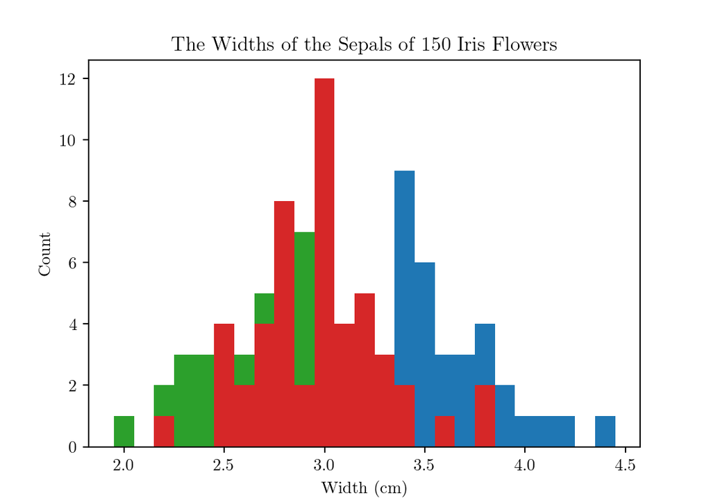

```python
import matplotlib.pyplot as plt
import numpy as np

# Settings
x = 6  # Want figures to be A6
plt.rc('figure', figsize=[46.82 * .5**(.5 * x), 33.11 * .5**(.5 * x)])
plt.rc('text', usetex=True)
plt.rc('font', family='serif')
plt.rc('text.latex', preamble=r'\usepackage{textgreek}')

# Create a data frame for each species of iris
setosa = iris_df[iris_df['Species'] == 0]
versicolor = iris_df[iris_df['Species'] == 1]
virginica = iris_df[iris_df['Species'] == 2]

# Plot
ax = plt.axes()
width = 0.1
# Count the number of occurrences of each sepal width for each species
uniq, cnts = np.unique(setosa['sepal width (cm)'], return_counts=1)
ax.bar(uniq, cnts, width, color='C0')
uniq, cnts = np.unique(versicolor['sepal width (cm)'], return_counts=1)
ax.bar(uniq, cnts, width, color='C2')
uniq, cnts = np.unique(virginica['sepal width (cm)'], return_counts=1)
ax.bar(uniq, cnts, width, color='C3')
# Set labels
ax.set_title('The Widths of the Sepals of 150 Iris Flowers')
ax.set_xlabel('Width (cm)')
ax.set_ylabel('Count')
# Finish
plt.show()
plt.close()
```

This has worked but there are two immediate problems:

- The fact that the data overlaps is confusing and it might be hiding some of the smaller bars in the back
- We can’t tell which species is which colour

Let’s fix the first of those problems first:

# 2 Separating Each Group’s Bars

By reducing the width of each bar to a third of its original width and offsetting each group of data, we can separate the bars as follows:

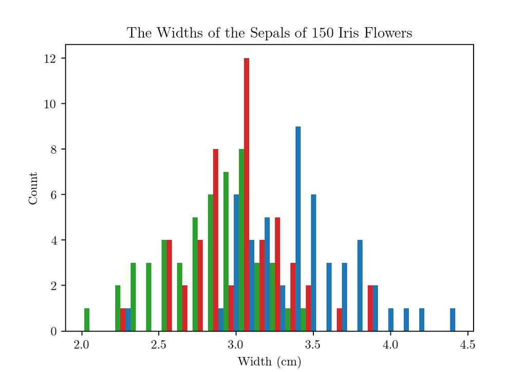

```python
# Plot
ax = plt.axes()
width = 0.1 / 3
# Count the number of occurrences of each sepal width for each species
uniq, cnts = np.unique(setosa['sepal width (cm)'], return_counts=1)
ax.bar(uniq, cnts, width, color='C0')
uniq, cnts = np.unique(versicolor['sepal width (cm)'], return_counts=1)
ax.bar(uniq + width, cnts, width, color='C2')
uniq, cnts = np.unique(virginica['sepal width (cm)'], return_counts=1)
ax.bar(uniq + 2 * width, cnts, width, color='C3')
# Set labels
ax.set_title('The Widths of the Sepals of 150 Iris Flowers')
ax.set_xlabel('Width (cm)')
ax.set_ylabel('Count')
# Finish
plt.show()
plt.close()
```

# 3 Adding a Legend

The easiest way to indicate which group is which is to use a legend:

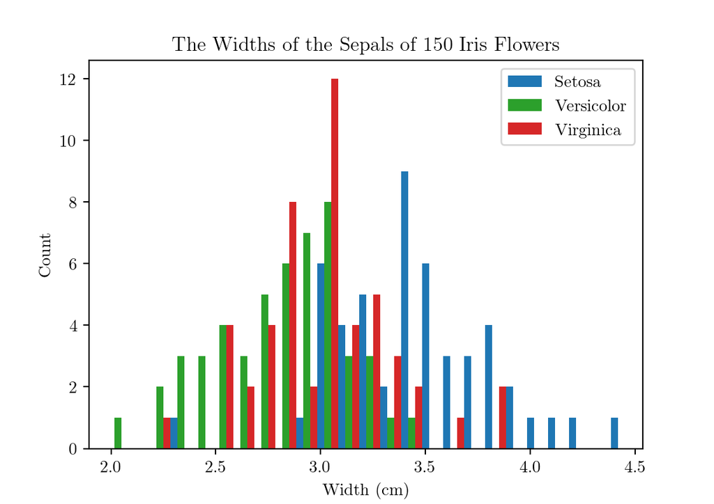

```python
# Plot
ax = plt.axes()
width = 0.1 / 3
# Count the number of occurrences of each sepal width for each species
uniq, cnts = np.unique(setosa['sepal width (cm)'], return_counts=1)
bar0 = ax.bar(uniq, cnts, width, color='C0')
uniq, cnts = np.unique(versicolor['sepal width (cm)'], return_counts=1)
bar1 = ax.bar(uniq + width, cnts, width, color='C2')
uniq, cnts = np.unique(virginica['sepal width (cm)'], return_counts=1)
bar2 = ax.bar(uniq + 2 * width, cnts, width, color='C3')
# Set labels
ax.set_title('The Widths of the Sepals of 150 Iris Flowers')
ax.set_xlabel('Width (cm)')
ax.set_ylabel('Count')
# Legend
ax.legend(
    (bar0[0], bar1[0], bar2[0]), ('Setosa', 'Versicolor', 'Virginica')
)
# Finish
plt.show()
plt.close()
```

# 4 Group Averages

Instead of plotting the width of every single sepal from every single flower, we can group all the sepals in one group together and only plot the means:

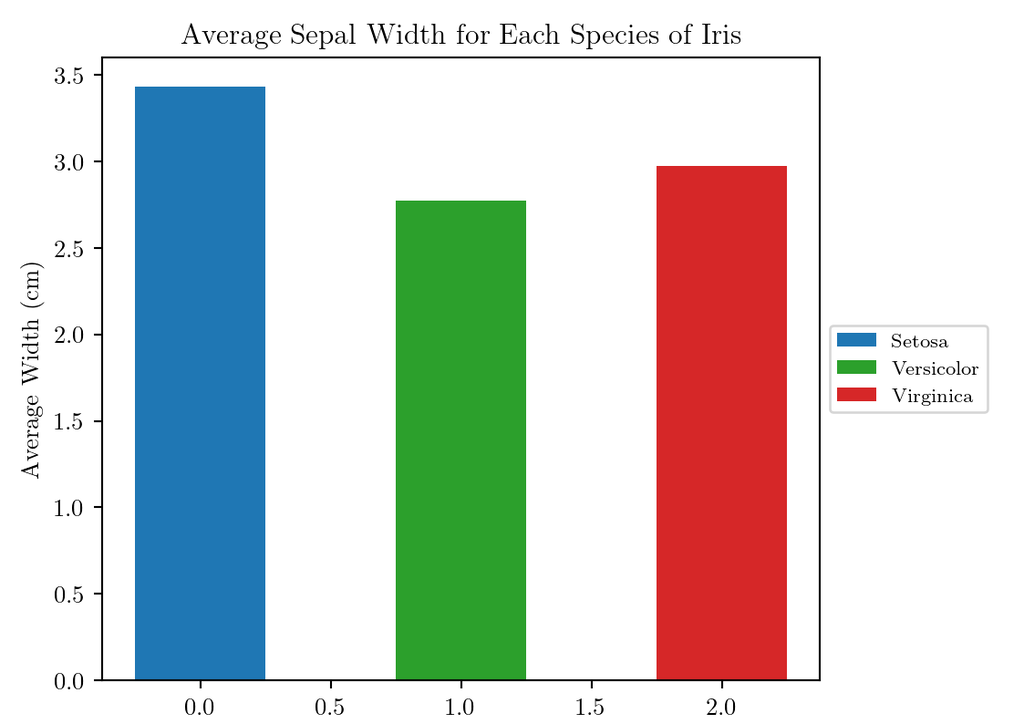

```python
# Plot with an adjusted shape to accommodate the legend
ax = plt.axes([0.1, 0.06, 0.7, 0.86])
width = 0.5
# Plot the average sepal width for each species
bar0 = ax.bar(0, setosa['sepal width (cm)'].mean(), width, color='C0')
bar1 = ax.bar(1, versicolor['sepal width (cm)'].mean(), width, color='C2')
bar2 = ax.bar(2, virginica['sepal width (cm)'].mean(), width, color='C3')
# Set labels
ax.set_title('Average Sepal Width for Each Species of Iris')
ax.set_xlabel('')
ax.set_ylabel('Average Width (cm)')
# Legend
plt.gca().legend(
    (bar0[0], bar1[0], bar2[0]), ('Setosa', 'Versicolor', 'Virginica'),
    fontsize=8, loc='center left', bbox_to_anchor=(1, 0.5)
)
# Finish
plt.show()
plt.close()
```

Note that, in order to fit the legend in, we had to adjust the size of the plot area with `ax = plt.axes([0.1, 0.06, 0.7, 0.86])`

> An important thing to realise at this point is that the first examples used ‘infinite bins’: each *sepal width* had a bar corresponding to it regardless of how many values there were. This previous example, however, is the opposite in that it only has *one bin* for each iris type. Essentially, all the bins have been compressed into one for each group. Later we will create plots that have a custom number of bins, between one and infinity.

## 4.1 x-Axis Tick Labels

Now that the x-axis corresponds to groups as opposed to values, it looks strange to have the scale on that axis be a continuous variable. Replace it with the group names using:

- The `ax.set_xticks()` command to define the positions of the ticks
- The `ax.set_xticklabels()` command to define the text for the tick labels

Note that both of these commands need to be used, in the order shown above, to get the desired output. Both functions take lists as their inputs.

Further customisation of the tick labels can be done using the `ax.tick_params()` function which has keyword arguments such as:

- `axis` to choose the axis whose tick labels you want to edit
- `length` to set the length of the ticks in points
- `rotation` to change the angle at which the tick labels are written
- `labelsize` to set the size of the tick labels. This argument will accept either a number (which gets interpreted as a font size with ‘points’ as the unit) or a string description (eg “large” or “small”).

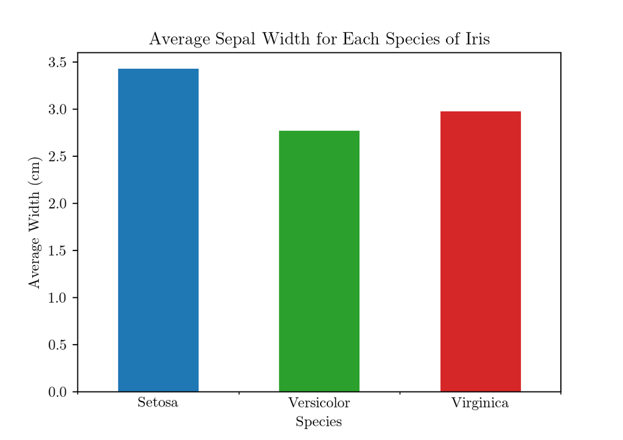

```python
# Plot
ax = plt.axes()
width = 0.5
# Plot the average sepal width for each species, including standard deviation
data0 = setosa['sepal width (cm)']
ax.bar(0, data0.mean(), width, color='C0')
data1 = versicolor['sepal width (cm)']
ax.bar(1, data1.mean(), width, color='C2')
data2 = virginica['sepal width (cm)']
ax.bar(2, data2.mean(), width, color='C3')
# Set labels
ax.set_title('Average Sepal Width for Each Species of Iris')
ax.set_xlabel('Species')
ax.set_ylabel('Average Width (cm)')
# x-Axis details
ax.set_xticks([0, 1, 2])
ax.set_xticklabels(['Setosa', 'Versicolor', 'Virginica'])
ax.tick_params(axis='x', length=0)
xlocs = np.arange(4) - 0.5
ax.set_xticks(xlocs, minor=True)
# Finish
plt.show()
plt.close()
```

## 4.2 Error Bars

The fact that each bar represents a number of values means that we can calculate a standard deviation for each, and represent that uncertainty on the graph as error bars:

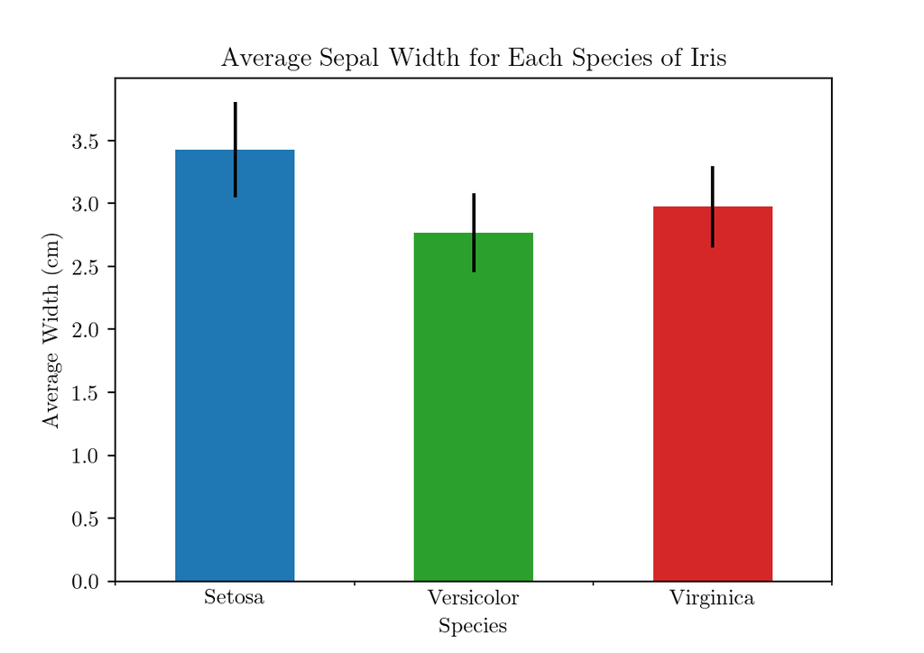

```python
# Plot
ax = plt.axes()
width = 0.5
# Plot the average sepal width for each species, including standard deviation
data0 = setosa['sepal width (cm)']
ax.bar([0], data0.mean(), width, color='C0', yerr=data0.std())
data1 = versicolor['sepal width (cm)']
ax.bar([1], data1.mean(), width, color='C2', yerr=data1.std())
data2 = virginica['sepal width (cm)']
ax.bar([2], data2.mean(), width, color='C3', yerr=data2.std())
# Set labels
ax.set_title('Average Sepal Width for Each Species of Iris')
ax.set_xlabel('Species')
ax.set_ylabel('Average Width (cm)')
# x-Axis details
ax.set_xticks([0, 1, 2])
ax.set_xticklabels(['Setosa', 'Versicolor', 'Virginica'])
ax.tick_params(axis='x', length=0)
xlocs = np.arange(4) - 0.5
ax.set_xticks(xlocs, minor=True)
# Finish
plt.show()
plt.close()
```

## 4.3 Plot the Individual Points

Instead of error bars, the spread of the data can be communicated by showing the data points themselves on top of the bars:

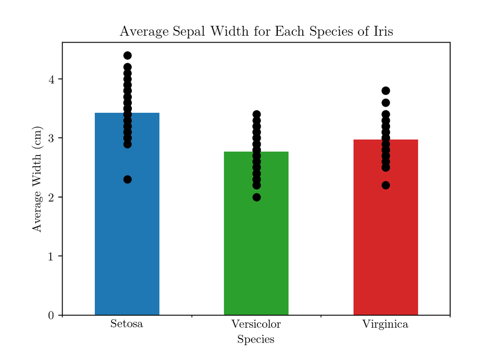

```python
# Plot
ax = plt.axes()
width = 0.5
# Separate out the three datasets
data0 = setosa['sepal width (cm)']
data1 = versicolor['sepal width (cm)']
data2 = virginica['sepal width (cm)']
# Plot the individual points
ax.scatter([0] * len(data0), data0, color='k')
ax.scatter([1] * len(data1), data1, color='k')
ax.scatter([2] * len(data2), data2, color='k')
# Plot the average sepal width for each species
ax.bar(0, data0.mean(), width, color='C0', zorder=0)
ax.bar(1, data1.mean(), width, color='C2', zorder=0)
ax.bar(2, data2.mean(), width, color='C3', zorder=0)
# Set labels
ax.set_title('Average Sepal Width for Each Species of Iris')
ax.set_xlabel('Species')
ax.set_ylabel('Average Width (cm)')
# x-Axis details
ax.set_xticks([0, 1, 2])
ax.set_xticklabels(['Setosa', 'Versicolor', 'Virginica'])
ax.tick_params(axis='x', length=0)
xlocs = np.arange(4) - 0.5
ax.set_xticks(xlocs, minor=True)
# Finish
plt.show()
plt.close()
```

## 4.4 Annotate the Values

Let’s show the height of each bar as a number on the plot itself:

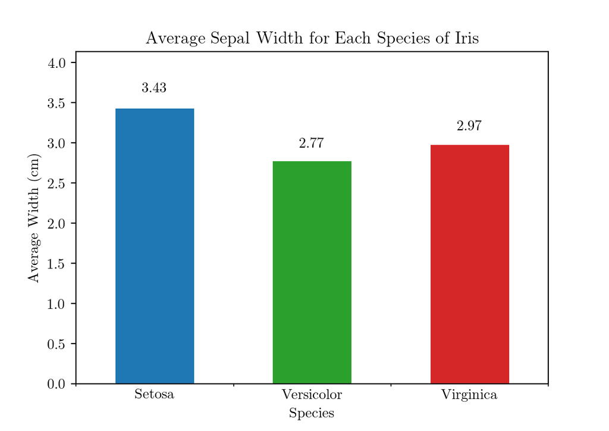

```python
# Plot
ax = plt.axes()
width = 0.5
# Separate out the three datasets
data0 = setosa['sepal width (cm)']
data1 = versicolor['sepal width (cm)']
data2 = virginica['sepal width (cm)']
# Plot the average sepal width for each species
ax.bar(0, data0.mean(), width, color='C0', zorder=0)
ax.bar(1, data1.mean(), width, color='C2', zorder=0)
ax.bar(2, data2.mean(), width, color='C3', zorder=0)
# Annotate the values above each bar
for bar in ax.patches:
    height = bar.get_height()
    ax.text(
        bar.get_x() + bar.get_width() / 2, 1.05 * height,
        f'{height:4.2f}', ha='center', va='bottom'
    )
# Increase the height of the plot by 15% to accommodate the labels
bottom, top = ax.get_ylim()
ax.set_ylim(bottom, top * 1.15)
# Set labels
ax.set_title('Average Sepal Width for Each Species of Iris')
ax.set_xlabel('Species')
ax.set_ylabel('Average Width (cm)')
# x-Axis details
ax.set_xticks(np.arange(len(ax.patches)))
ax.set_xticklabels(['Setosa', 'Versicolor', 'Virginica'])
ax.tick_params(axis='x', length=0)
xlocs = np.arange(len(ax.patches) + 1) - 0.5
ax.set_xticks(xlocs, minor=True)
# Finish
plt.show()
plt.close()
```

# 5 Custom Bins

## 5.1 Stratification - Introducing an Additional Variable

This time we will stratify the data into long (6.5+ cm), medium (5.5 to 6.5 cm) and short (0 to 5.5 cm) sepals and plot the average sepal width for each group for each stratification:

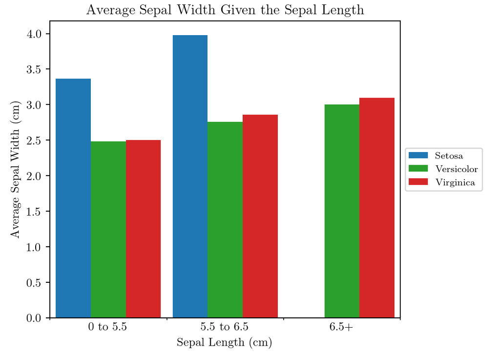

```python
# Separate out the three datasets
discriminator = 'sepal length (cm)'
data0 = [
    setosa[setosa[discriminator] < 5.5]['sepal width (cm)'].mean(),
    setosa[(setosa[discriminator] >= 5.5) & (setosa[discriminator] < 6.5)]['sepal width (cm)'].mean(),
    setosa[setosa[discriminator] >= 6.5]['sepal width (cm)'].mean()
]
data1 = [
    versicolor[versicolor[discriminator] < 5.5]['sepal width (cm)'].mean(),
    versicolor[(versicolor[discriminator] >= 5.5) & (versicolor[discriminator] < 6.5)]['sepal width (cm)'].mean(),
    versicolor[versicolor[discriminator] >= 6.5]['sepal width (cm)'].mean()
]
data2 = [
    virginica[virginica[discriminator] < 5.5]['sepal width (cm)'].mean(),
    virginica[(virginica[discriminator] >= 5.5) & (virginica[discriminator] < 6.5)]['sepal width (cm)'].mean(),
    virginica[virginica[discriminator] >= 6.5]['sepal width (cm)'].mean()
]

# Plot with an adjusted shape to accommodate the legend
# The four values set the following: [left, bottom, width, height]
ax = plt.axes([0.1, 0.1, 0.7, 0.84])
width = 0.3
bar0 = ax.bar(
    np.arange(len(data0)) - width, data0, width,
    color='C0'
)
bar1 = ax.bar(
    np.arange(len(data1)), data1, width,
    color='C2'
)
bar2 = ax.bar(
    np.arange(len(data2)) + width, data2, width,
    color='C3'
)
# Set labels
ax.set_title('Average Sepal Width Given the Sepal Length')
ax.set_xlabel('Sepal Length (cm)')
ax.set_ylabel('Average Sepal Width (cm)')
# x-Axis details
ax.set_xticks([0, 1, 2])
ax.set_xticklabels(['0 to 5.5', '5.5 to 6.5', '6.5+'])
ax.tick_params(axis='x', length=0)
xlocs = np.arange(len(data1) + 1) - 0.5
ax.set_xticks(xlocs, minor=True)
ax.set_xlim([min(xlocs), max(xlocs)])
# Legend
plt.gca().legend(
    (bar0[0], bar1[0], bar2[0]), ('Setosa', 'Versicolor', 'Virginica'),
    fontsize=8, loc='center left', bbox_to_anchor=(1, 0.5)
)
# Finish
plt.show()
plt.close()
```

## 5.2 Add Annotations

As before, let’s add the height above each bar:

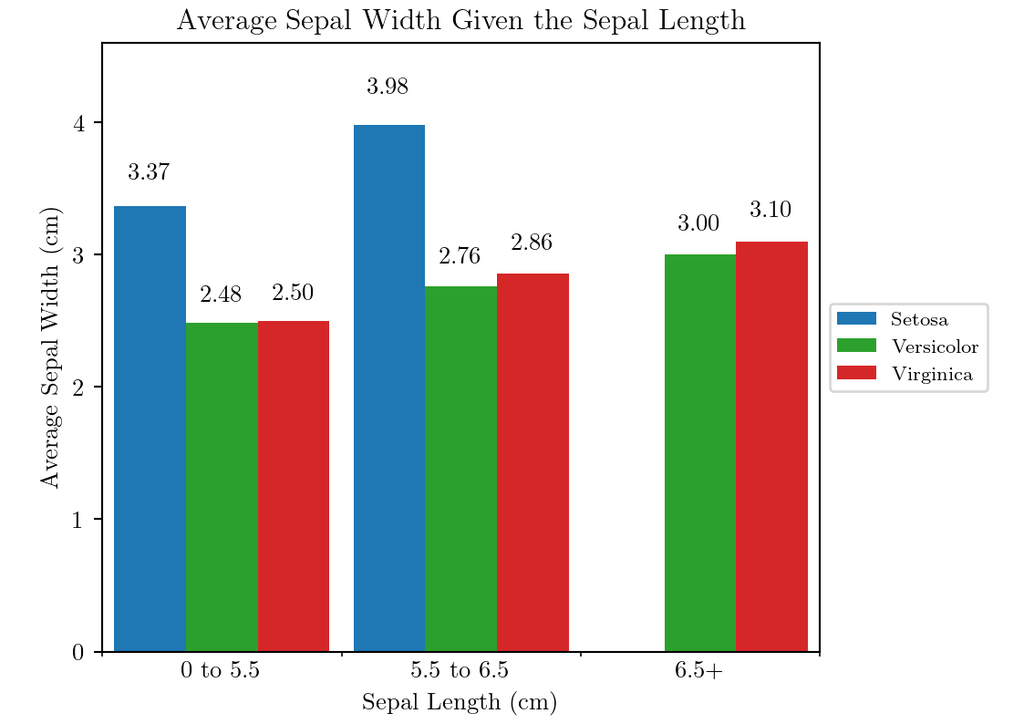

```python
# Separate out the three datasets
discriminator = 'sepal length (cm)'
data0 = [
    setosa[setosa[discriminator] < 5.5]['sepal width (cm)'].mean(),
    setosa[(setosa[discriminator] >= 5.5) & (setosa[discriminator] < 6.5)]['sepal width (cm)'].mean(),
    setosa[setosa[discriminator] >= 6.5]['sepal width (cm)'].mean()
]
data1 = [
    versicolor[versicolor[discriminator] < 5.5]['sepal width (cm)'].mean(),
    versicolor[(versicolor[discriminator] >= 5.5) & (versicolor[discriminator] < 6.5)]['sepal width (cm)'].mean(),
    versicolor[versicolor[discriminator] >= 6.5]['sepal width (cm)'].mean()
]
data2 = [
    virginica[virginica[discriminator] < 5.5]['sepal width (cm)'].mean(),
    virginica[(virginica[discriminator] >= 5.5) & (virginica[discriminator] < 6.5)]['sepal width (cm)'].mean(),
    virginica[virginica[discriminator] >= 6.5]['sepal width (cm)'].mean()
]

# Plot with an adjusted shape to accommodate the legend
# The four values set the following: [left, bottom, width, height]
ax = plt.axes([0.1, 0.1, 0.7, 0.84])
width = 0.3
bar0 = ax.bar(
    np.arange(len(data0)) - width, data0, width,
    color='C0'
)
bar1 = ax.bar(
    np.arange(len(data1)), data1, width,
    color='C2'
)
bar2 = ax.bar(
    np.arange(len(data2)) + width, data2, width,
    color='C3'
)
# Annotate the values above each bar
for bar in ax.patches:
    height = bar.get_height()
    ax.text(
        bar.get_x() + bar.get_width() / 2, 1.05 * height,
        f'{height:4.2f}', ha='center', va='bottom'
    )
# Increase the height of the plot by 10% to accommodate the labels
bottom, top = ax.get_ylim()
ax.set_ylim(bottom, top * 1.10)
# Set labels
ax.set_title('Average Sepal Width Given the Sepal Length')
ax.set_xlabel('Sepal Length (cm)')
ax.set_ylabel('Average Sepal Width (cm)')
# x-Axis details
ax.set_xticks([0, 1, 2])
ax.set_xticklabels(['0 to 5.5', '5.5 to 6.5', '6.5+'])
ax.tick_params(axis='x', length=0)
xlocs = np.arange(len(data1) + 1) - 0.5
ax.set_xticks(xlocs, minor=True)
ax.set_xlim([min(xlocs), max(xlocs)])
# Legend
plt.gca().legend(
    (bar0[0], bar1[0], bar2[0]), ('Setosa', 'Versicolor', 'Virginica'),
    fontsize=8, loc='center left', bbox_to_anchor=(1, 0.5)
)
# Finish
plt.show()
plt.close()
```

## 5.3 Dual Axes

Instead of using a legend, we can show that we are plotting different groups by having two y-axes that correspond to the colour of the group they refer to:

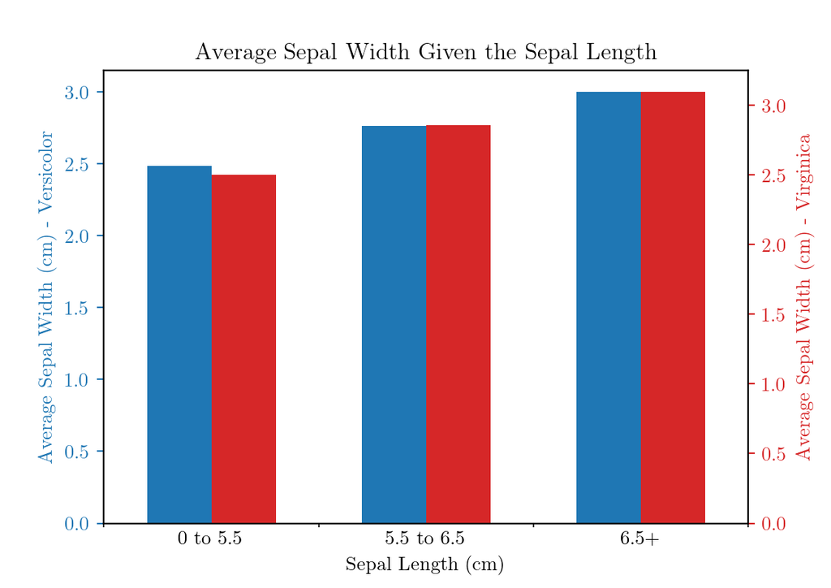

```python
# Plot with an adjusted shape to accommodate the legend
ax = plt.axes()
width = 0.3
ax.bar(np.arange(len(data1)) - 0.15, data1, width, color='C0')
# Set labels
ax.set_title('Average Sepal Width Given the Sepal Length')
ax.set_xlabel('Sepal Length (cm)')
ax.set_ylabel('Average Sepal Width (cm) - Versicolor', color='C0')
ax.tick_params(axis='y', colors='C0')
# x-Axis details
ax.set_xticks(np.arange(len(data1)))
ax.set_xticklabels(['0 to 5.5', '5.5 to 6.5', '6.5+'])
ax.tick_params(axis='x', length=0)
xlocs = np.arange(len(data1) + 1) - 0.5
ax.set_xticks(xlocs, minor=True)
ax.set_xlim([min(xlocs), max(xlocs)])
# Second y-axis
ax2 = ax.twinx()
ax2.bar(np.arange(len(data2)) + 0.15, data2, width, color='C3')
ax2.set_ylabel('Average Sepal Width (cm) - Virginica', color='C3')
ax2.tick_params(axis='y', colors='C3')
# Finish
plt.show()
plt.close()
```

# 6 Colours and Formatting

All the formatting options detailed in the [Bar Plots with One Group of Data](https://rowannicholls.github.io/python/graphs/ax_based/barplots_single_group.html) page can be used here, including outlining the bars with the `edgecolor` and `linewidth` parameters:

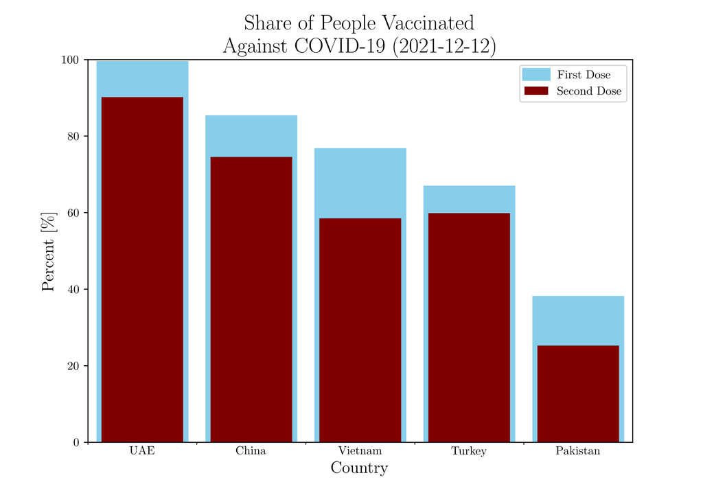

```python
import numpy as np
import matplotlib.pyplot as plt

# Settings
x = 5  # Want figures to be A5
plt.rc('figure', figsize=[46.82 * .5**(.5 * x), 33.11 * .5**(.5 * x)])
plt.rc('text', usetex=True)
plt.rc('font', family='serif')
plt.rc('text.latex', preamble=r'\usepackage{textgreek}')

# Custom Colours
skyblue = '#87CEEB'
maroon = '#800000'

# Create data
first_dose = {'UAE': 98.99, 'China': 84.83, 'Vietnam': 76.23, 'Turkey': 66.46, 'Pakistan': 37.65,}
second_dose = {'UAE': 90.18, 'China': 74.53, 'Vietnam': 58.51, 'Turkey': 59.87, 'Pakistan': 25.25,}

#
# Plot
#
ax = plt.axes()
for i, item in enumerate(first_dose.items()):
    country = item[0]
    dose1 = first_dose[country]
    dose2 = second_dose[country]
    bar1 = ax.bar(i, dose1, 0.8, color=skyblue, edgecolor=skyblue, linewidth=4)
    bar2 = ax.bar(i, dose2, 0.75, color=maroon)
# Set labels
ax.set_title('Share of People Vaccinated\nAgainst COVID-19 (2021-12-12)', fontsize=18)
ax.set_xlabel('Country', fontsize=14)
ax.set_ylabel(r'Percent [\%]', fontsize=14)
# y-Axis details
ax.set_ylim(0, 100)
# x-Axis details
ax.set_xticks(np.arange(len(first_dose)))
ax.set_xticklabels(first_dose.keys())
ax.tick_params(axis='x', length=0)
xlocs = np.arange(len(first_dose)) - 0.5
ax.set_xticks(xlocs, minor=True)
ax.set_xlim(-0.5, len(first_dose) - 0.5)
# Legend
plt.gca().legend(
    (bar1[0], bar2[0]), ('First Dose', 'Second Dose'),
    fontsize=10
)
# Finished
plt.show()
plt.close()
```

# 7 Save Plot

Finally, use `plt.savefig('name_of_plot.png')` to save the plot to your computer.

⇦ Back